# Content Opportunity Scoring & Refresh Prioritization with Machine Learning

## Abstract

This study asks which content pages should be reviewed first when a content team has limited time and needs a ranked, evidence-based queue. Using March 2026 search and engagement signals from the anonymized FlyRank internship warehouse, the analysis defines a decline proxy from the March-versus-February change in Google Search Console impressions and compares a transparent rule with logistic regression and a Random Forest under client-grouped validation. The Random Forest achieved a grouped AUC of **0.721**, slightly above logistic regression at **0.719** and materially above the rule baseline at **0.500**, with a March decline base rate of **20.1%**. The result supports using the model as a ranking aid for human review, while also showing that `log_impressions_mar` is the strongest contributor and that the model should not be interpreted as a causal explanation of traffic loss. The study is limited by its two-month proxy label, single-month evaluation snapshot, client cold-start risk, and the fact that only the **Protect** and **Refresh** actions are model-backed; the remaining actions are transparent heuristics.

## 1. Introduction / Problem Statement

**Research question:** *Which content pages should be reviewed first, based on search visibility, engagement, freshness, and decline signals?*

**Decision this supports:** prioritizing a limited weekly review queue so a content/SEO team spends its first few hours on the pages most worth the time.

**Who acts on it:** SEO specialists and content editors, who then review, refresh, expand, prune, or monitor a page.

**Cost of a wrong call:**

- **False positive:** a healthy page gets reviewed unnecessarily, wasting editor time.
- **False negative:** a page that genuinely needs attention gets skipped, and the observed decline may continue.

**Why ML is useful here:** earlier analysis found no single candidate signal with a strong standalone relationship to the decline proxy. The goal is therefore not to replace a human rulebook with an opaque decision, but to combine several weak/heterogeneous signals into a ranked review queue. The final framing is intentionally modest: current impressions are the strongest contributor, so the model's value is primarily in ranking pages for attention rather than explaining why traffic changed.

## 2. Data

*Which release, which tables, date windows, what you excluded and why. Public-safe.*

**Source:** FlyRank internship warehouse (`FlyRank/internship-warehouse`, build `v20260703`), queried directly from Parquet with DuckDB.

**Base grain:** one row in `fact_content_daily_performance` is one `(report_date, client_hash_id, content_hash_id)` daily performance record.

**Feature / label grain:** one row per content item and client, aggregated over a calendar month.

### Time windows

- **Feature window:** `2026-03-01` → `2026-03-31` (`month=2026-03`).
- **Comparison window:** `2026-02-01` → `2026-02-28` (`month=2026-02`), used only to define the decline proxy.
- **Decision cutoff:** 2026-03-31. No April 2026 or later performance data is used.

### Tables

- `fact_content_daily_performance`: GSC impressions/clicks/position and GA4 pageviews/session/engagement signals.
- `dim_content`: content type and content dates used for freshness and population filtering.

### Exclusions

- `fact_content_query_90d` is excluded because its fixed 90-day window can overlap the sealed label period.
- April 2026 or later data is excluded as future information.
- GA4 placeholder rows with `ga4_data_available IS FALSE` are not treated as genuine zero engagement.
- Pipeline metadata, account-admin fields, URLs, names, and raw queries are not model inputs.
- Deleted or unpublished content is excluded from the analysis population.

### Public safety

The public paper contains no client names, domains, raw URLs, raw search queries, credentials, tokens, or sensitive identifiers. Pseudonymous hash fields are used only for joins/grouping in the analysis.

```
Mode: REPORT MODE (validated results)
Snapshot: 2026-03-31 | feature month: 2026-03 | comparison month: 2026-02
```

```
Live model path skipped. No credentials were requested or stored.
```

## 3. Methodology

*Assumptions, features, label definition, baseline, validation design, leakage checks.*

**Leakage controls:**

1. February impressions and the March-vs-February change are label-only.
2. Rule outputs such as `baseline_score`, `reason_code`, and `action_label` are not model features.
3. No April 2026+ performance is queried.
4. Client-grouped validation prevents pages from the same client appearing in both train and validation folds.
5. The earlier leakage experiment showed why label-derived features are invalid: an intentionally leaked model reached AUC 1.000, while removing the leak produced a much more credible result.

**Model:** Random Forest with 300 trees, maximum depth 8, minimum leaf size 20, balanced class weights, compared with logistic regression.

**Baseline:** the transparent AND-gate from `w04`, requiring enough impressions, sufficient age, no cooldown, staleness, and a position-band-relative CTR gap. It flagged only **1 of 134,086 pages** in the validated cycle.

**Validation:** 5-fold `GroupKFold` by `client_hash_id`. The validated grouped AUCs are 0.719 for logistic regression and 0.721 for Random Forest. Naive KFold gave 0.742 and 0.771 respectively, illustrating why client grouping matters.

## 4. Results (vs baseline)

*Model vs baseline on the same split. The honest table.*

Scroll table sideways for more columns

| # | Model | Grouped AUC | Lift vs. Baseline |
| --- | --- | --- | --- |
| 0 | Baseline rule | 0.500 | 0.000 |
| 1 | Logistic regression | 0.719 | 0.219 |
| 2 | Random forest | 0.721 | 0.221 |

Scroll table sideways for more columns

| # | Top-K | Baseline Precision | Logistic Regression Precision | Random Forest Precision | RF Lift over Base Rate |
| --- | --- | --- | --- | --- | --- |
| 0 | 10 | 0.40 | 0.80 | 1.00 | 0.799 |
| 1 | 20 | 0.35 | 0.80 | 1.00 | 0.799 |
| 2 | 50 | 0.22 | 0.62 | 0.96 | 0.759 |
| 3 | 100 | 0.14 | 0.69 | 0.95 | 0.749 |

Scroll table sideways for more columns

| # | Model | Naive K-Fold AUC | Grouped K-Fold AUC | Overstatement |
| --- | --- | --- | --- | --- |
| 0 | Logistic regression | 0.742 | 0.719 | 0.023 |
| 1 | Random forest | 0.771 | 0.721 | 0.050 |

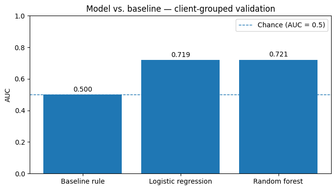

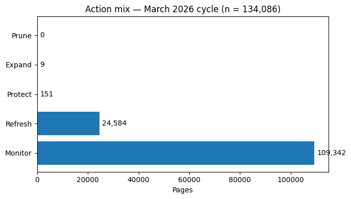

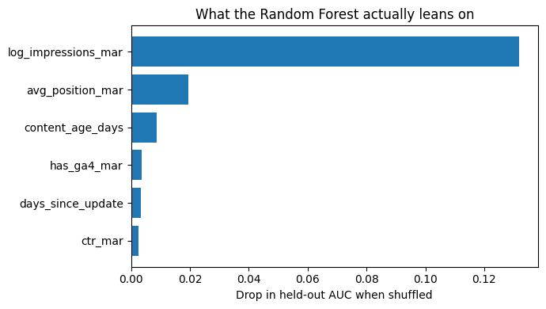

All headline numbers below are the **client-grouped, honest** validation results.

Scroll table sideways for more columns

| Model | Grouped AUC | Lift vs. baseline |
| --- | --- | --- |
| Baseline rule | 0.500 | — |
| Logistic regression | 0.719 | +0.219 |
| **Random Forest** | **0.721** | **+0.221** |

**Base rate:** 20.1%.

Scroll table sideways for more columns

| K | Baseline | Logistic regression | Random Forest |
| --- | --- | --- | --- |
| 10 | 0.40 | 0.80 | **1.00** |
| 20 | 0.35 | 0.80 | **1.00** |
| 50 | 0.22 | 0.62 | **0.96** |
| 100 | 0.14 | 0.69 | **0.95** |

Note: the baseline has only one non-zero-scored page in the validated 134,086-page population, so precision beyond the first tied item is not a meaningful ranking measure.

The headline is deliberately narrow: on this held-out, client-grouped split, the Random Forest ranked observed-decline pages better than the transparent rule. It does **not** prove that a flagged page will recover if refreshed, and it does not predict Google's algorithm.

## 5. Limitations

*What this work cannot claim.*

Permutation importance shows that `log_impressions_mar` is the dominant contributor (**0.1317**), followed by `avg_position_mar` (**0.0194**) and `content_age_days` (**0.0086**). This makes the model useful as a ranking tool, but it also limits how much we should say about the underlying mechanism: current search visibility is doing much of the work.

Key limitations:

- The label is a two-month proxy and cannot separate content effects from seasonality or client-wide SERP changes.
- The evaluation covers one snapshot month.
- New-client / cold-start behavior remains uncertain; grouped validation is more honest than naive row-level splitting but does not solve unseen-client generalization.
- `avg_position_mar` has a known no-data-day averaging bias that can affect marginal ranking.
- Only **Protect** and **Refresh** are model-backed. **Expand**, **Prune**, and **Monitor** are transparent heuristics with no ground-truth action label, so no precision/AUC is reported for them.
- The label measures search-visibility decline, not revenue, conversions, or business value.

**What this work does not claim:** it does not claim to predict Google's ranking algorithm, prove a causal impact of content changes, or replace editorial judgment.

## 6. Ranked recommendations

*The action playbook output — the paper's recommendations section.*

Scroll table sideways for more columns

| Rank | Action | Evidence | March 2026 pages |
| --- | --- | --- | --- |
| 1 | **Protect** | Model-backed: high-value pages flagged as declining | 151 |
| 2 | **Refresh** | Model-backed: declining, stale/underperforming pages | 24,584 |
| 3 | **Expand** | Rule/heuristic: thin content with real demand | 9 |
| 4 | **Prune** | Rule/heuristic: dead + old | 0 |
| 5 | **Monitor** | Rule/heuristic: default / low signal | 109,342 |

### Human review before action

- Check that the reason code matches the row's observed signals.
- Check for seasonality, campaigns, redesigns, or other known business context.
- Check possible cannibalization before acting on a `protect` or `refresh` recommendation.
- Never auto-delete or unpublish a `prune` page.
- Never bulk-refresh without duplicate-content review.
- Treat low-confidence rows as requiring review, not as evidence that a page is unimportant.

**Drift watch:** monitor out-of-time precision, editor override rates, action mix, and first-cycle performance for new clients.

## 7. Reproducibility

*Generate/collect the charts and tables your deployed page will show.*

Repository: mahidimithun/flyrank-ml-internship

Capstone notebook: `work/notebooks/capstone.ipynb`

Earlier research notebooks: `work/notebooks/w01_*` through `work/notebooks/w07_*`. The capstone preserves their research chain rather than replacing it.

### Live reproduction

1. Install the repository requirements, including DuckDB, pandas, matplotlib, NumPy, and scikit-learn.
2. Obtain approved read access to the Hugging Face dataset `FlyRank/internship-warehouse`.
3. Set `HF_TOKEN` in the execution environment **without committing it**.
4. Set `RUN_LIVE_MODEL = True`.
5. Run the notebook top-to-bottom.
6. The live path constructs `feature_frame`, `X`, `y`, and `groups`, then runs logistic regression, Random Forest, `GroupKFold`, out-of-fold predictions, AUC, and the report charts.

The public/report mode is intentionally credential-free and reproduces the validated tables and figures without pretending that a warehouse run occurred in this environment.

## 8. Acknowledgments & Data Credit

This project was completed as part of the **FlyRank ML Internship**, under **Lane 2: Refresh / Content Opportunity Scoring**.

Built on the [FlyRank ML Internship](https://flyrank.ai) dataset.

**Primary data source:** FlyRank Internship Warehouse — the pseudonymized warehouse dataset provided by **FlyRank AI** and hosted on Hugging Face.

**Hugging Face dataset:** FlyRank/internship-warehouse

**Dataset release used:** `v20260703`. The analysis uses the `fact_content_daily_performance`, and `dim_content`tables, with the specific date windows and exclusions documented in Section 2.

The dataset is used for **anonymized research and education purposes**. No attempt was made to re-identify clients, domains, queries, keywords, or content, and no raw client-identifying data, credentials, or tokens are included in this public report.

**Data credit:** FlyRank AI — [FlyRank Internship Warehouse on Hugging Face](https://huggingface.co/datasets/FlyRank/internship-warehouse).